# Cx4073 : Assignment 1

Shantanu Sharma

U1622895F

### Analysis of Naval Propulsion Data

Import the CSV data file `assign1_NavalData.csv` for analysis, and quickly check the structure of the data.

```r
navalData <- read.csv("assign1_NavalData.csv", header = TRUE)
str(navalData)
```

```
## 'data.frame':    10000 obs. of  18 variables:
##  $ X1 : num  3.14 7.15 5.14 4.16 9.3 9.3 2.09 1.14 8.21 8.21 ...
##  $ X2 : int  9 21 15 12 27 27 6 3 24 24 ...
##  $ X3 : num  8374 39007 21639 14722 72759 ...
##  $ X4 : num  1387 2678 1924 1547 3560 ...
##  $ X5 : num  7014 9116 8514 7758 9729 ...
##  $ X6 : num  60.3 332.5 175.3 113.8 644.7 ...
##  $ X7 : num  60.3 332.5 175.3 113.8 644.7 ...
##  $ X8 : num  586 822 705 653 1058 ...
##  $ X9 : int  288 288 288 288 288 288 288 288 288 288 ...
##  $ X10: num  578 687 640 610 772 ...
##  $ X11: num  1.39 2.99 2.07 1.66 4.55 4.52 1.33 1.26 3.6 3.58 ...
##  $ X12: int  1 1 1 1 1 1 1 1 1 1 ...
##  $ X13: num  7.6 15.71 10.92 9.01 22.96 ...
##  $ X14: num  1.02 1.04 1.03 1.02 1.05 1.05 1.02 1.02 1.04 1.04 ...
##  $ X15: num  12.3 44 24.9 17.8 88.3 ...
##  $ X16: num  0.24 0.87 0.49 0.35 1.75 1.79 0.26 0.25 1.18 1.22 ...
##  $ Y1 : num  0.99 0.99 0.95 0.97 1 0.97 0.99 0.99 1 0.96 ...
##  $ Y2 : num  0.98 0.98 1 0.98 0.98 0.98 1 0.99 0.99 0.98 ...
```

The following table summarizes the features/variables in the dataset. You will also find them in the text file `assign1_FeatureNames.txt`. The features/variables `X1` to `X16` are the predictors, while `Y1` and `Y2` are the *target* response variables.

| Variable | Description |
| --- | --- |
| X1 | Lever position (lp) |
| X2 | Ship speed (v) [knots] |
| X3 | Gas Turbine shaft torque (GTT) [kN m] |
| X4 | Gas Turbine rate of revolutions (GTn) [rpm] |
| X5 | Gas Generator rate of revolutions (GGn) [rpm] |
| X6 | Starboard Propeller Torque (Ts) [kN] |
| X7 | Port Propeller Torque (Tp) [kN] |
| X8 | HP Turbine exit temperature (T48) [C] |
| X9 | GT Compressor inlet air temperature (T1) [C] |
| X10 | GT Compressor outlet air temperature (T2) [C] |
| X11 | HP Turbine exit pressure (P48) [bar] |
| X12 | GT Compressor inlet air pressure (P1) [bar] |
| X13 | GT Compressor outlet air pressure (P2) [bar] |
| X14 | Gas Turbine exhaust gas pressure (Pexh) [bar] |
| X15 | Turbine Injecton Control (TIC) [%] |
| X16 | Fuel flow (mf) [kg/s] |
| Y1 | GT Compressor decay state coefficient |
| Y2 | GT Turbine decay state coefficient |

The data is from a simulator of a naval vessel, characterized by a Gas Turbine (GT) propulsion plant. You may treat the available data as if it is from a hypothetical naval vessel. The propulsion system behaviour has been described with the parameters `X1` to `X16`, as detailed above, and the target is to predict the performance decay of the GT components such as *GT Compressor* and *GT Turbine*.

**Task** : Build the best possible Linear Model you can to predict both `Y1` and `Y2`, using the training dataset `assign1_NavalData.csv`. Then predict `Y1` and `Y2` values using your model on the test dataset `assign1_NavalPred.csv`.

# Part 1- Analysis

## Aim 1:

Basic analysis of the dataset

```r
dim(navalData)
```

```
## [1] 10000    18
```

```r
names(navalData)
```

```
##  [1] "X1"  "X2"  "X3"  "X4"  "X5"  "X6"  "X7"  "X8"  "X9"  "X10" "X11" "X12"
## [13] "X13" "X14" "X15" "X16" "Y1"  "Y2"
```

```r
str(navalData)
```

```
## 'data.frame':    10000 obs. of  18 variables:
##  $ X1 : num  3.14 7.15 5.14 4.16 9.3 9.3 2.09 1.14 8.21 8.21 ...
##  $ X2 : int  9 21 15 12 27 27 6 3 24 24 ...
##  $ X3 : num  8374 39007 21639 14722 72759 ...
##  $ X4 : num  1387 2678 1924 1547 3560 ...
##  $ X5 : num  7014 9116 8514 7758 9729 ...
##  $ X6 : num  60.3 332.5 175.3 113.8 644.7 ...
##  $ X7 : num  60.3 332.5 175.3 113.8 644.7 ...
##  $ X8 : num  586 822 705 653 1058 ...
##  $ X9 : int  288 288 288 288 288 288 288 288 288 288 ...
##  $ X10: num  578 687 640 610 772 ...
##  $ X11: num  1.39 2.99 2.07 1.66 4.55 4.52 1.33 1.26 3.6 3.58 ...
##  $ X12: int  1 1 1 1 1 1 1 1 1 1 ...
##  $ X13: num  7.6 15.71 10.92 9.01 22.96 ...
##  $ X14: num  1.02 1.04 1.03 1.02 1.05 1.05 1.02 1.02 1.04 1.04 ...
##  $ X15: num  12.3 44 24.9 17.8 88.3 ...
##  $ X16: num  0.24 0.87 0.49 0.35 1.75 1.79 0.26 0.25 1.18 1.22 ...
##  $ Y1 : num  0.99 0.99 0.95 0.97 1 0.97 0.99 0.99 1 0.96 ...
##  $ Y2 : num  0.98 0.98 1 0.98 0.98 0.98 1 0.99 0.99 0.98 ...
```

```r
head(navalData)
```

```
##     X1 X2       X3      X4      X5     X6     X7      X8  X9    X10  X11 X12
## 1 3.14  9  8373.85 1386.72 7013.62  60.28  60.28  585.98 288 578.07 1.39   1
## 2 7.15 21 39007.12 2678.01 9116.04 332.49 332.49  821.74 288 686.53 2.99   1
## 3 5.14 15 21639.19 1924.36 8513.72 175.32 175.32  705.11 288 640.12 2.07   1
## 4 4.16 12 14721.84 1547.46 7757.85 113.78 113.78  653.07 288 610.15 1.66   1
## 5 9.30 27 72759.21 3560.37 9729.10 644.74 644.74 1057.88 288 771.58 4.55   1
## 6 9.30 27 72763.86 3560.39 9755.85 644.76 644.76 1086.81 288 780.50 4.52   1
##     X13  X14   X15  X16   Y1   Y2
## 1  7.60 1.02 12.35 0.24 0.99 0.98
## 2 15.71 1.04 43.97 0.87 0.99 0.98
## 3 10.92 1.03 24.89 0.49 0.95 1.00
## 4  9.01 1.02 17.77 0.35 0.97 0.98
## 5 22.96 1.05 88.27 1.75 1.00 0.98
## 6 22.85 1.05 90.41 1.79 0.97 0.98
```

```r
tail(navalData)
```

```
##         X1 X2       X3      X4      X5     X6     X7      X8  X9    X10  X11
## 9995  7.15 21 39003.56 2678.03 9117.88 332.36 332.36  826.01 288 688.20 2.98
## 9996  8.21 24 50980.73 3087.03 9292.11 437.85 437.85  922.31 288 727.73 3.61
## 9997  9.30 27 72769.02 3560.39 9751.42 644.80 644.80 1068.72 288 775.77 4.52
## 9998  9.30 27 72771.02 3560.40 9747.98 644.90 644.90 1056.83 288 772.58 4.53
## 9999  5.14 15 21624.59 1924.34 8468.24 175.25 175.25  683.49 288 629.30 2.09
## 10000 2.09  6  4500.88 1392.71 6842.73  31.20  31.20  534.26 288 564.56 1.26
##       X12   X13  X14   X15  X16   Y1   Y2
## 9995    1 15.71 1.04 44.23 0.88 0.99 0.98
## 9996    1 18.79 1.04 60.69 1.20 1.00 0.98
## 9997    1 22.69 1.05 88.78 1.76 0.98 0.99
## 9998    1 22.61 1.05 87.72 1.74 0.99 0.99
## 9999    1 11.01 1.03 23.91 0.47 1.00 1.00
## 10000   1  6.73 1.02  0.00 0.17 0.97 1.00
```

### Observation 1:

10,000 data points and 18 variables in the given dataset with X2, X9, X12 being integer values

## Aim 2:

Generate summary of variables is first generated to have a vague idea about the distribution of variables individually.

```r
summary(navalData)
```

```
##        X1              X2              X3                X4
##  Min.   :1.140   Min.   : 3.00   Min.   :  253.6   Min.   :1308
##  1st Qu.:3.140   1st Qu.: 9.00   1st Qu.: 8375.9   1st Qu.:1387
##  Median :5.140   Median :15.00   Median :21630.7   Median :1924
##  Mean   :5.162   Mean   :14.98   Mean   :27160.0   Mean   :2134
##  3rd Qu.:7.150   3rd Qu.:21.00   3rd Qu.:39001.2   3rd Qu.:2678
##  Max.   :9.300   Max.   :27.00   Max.   :72783.3   Max.   :3561
##        X5             X6               X7               X8
##  Min.   :6589   Min.   :  5.30   Min.   :  5.30   Min.   : 444.7
##  1st Qu.:7058   1st Qu.: 60.32   1st Qu.: 60.32   1st Qu.: 590.0
##  Median :8482   Median :175.27   Median :175.27   Median : 706.0
##  Mean   :8198   Mean   :226.51   Mean   :226.51   Mean   : 734.9
##  3rd Qu.:9132   3rd Qu.:332.36   3rd Qu.:332.36   3rd Qu.: 833.6
##  Max.   :9797   Max.   :645.25   Max.   :645.25   Max.   :1115.8
##        X9           X10             X11             X12         X13
##  Min.   :288   Min.   :541.0   Min.   :1.090   Min.   :1   Min.   : 5.83
##  1st Qu.:288   1st Qu.:578.1   1st Qu.:1.390   1st Qu.:1   1st Qu.: 7.45
##  Median :288   Median :637.1   Median :2.080   Median :1   Median :11.09
##  Mean   :288   Mean   :646.0   Mean   :2.349   Mean   :1   Mean   :12.28
##  3rd Qu.:288   3rd Qu.:693.8   3rd Qu.:2.980   3rd Qu.:1   3rd Qu.:15.66
##  Max.   :288   Max.   :789.1   Max.   :4.560   Max.   :1   Max.   :23.14
##       X14            X15             X16               Y1
##  Min.   :1.02   Min.   : 0.00   Min.   :0.0700   Min.   :0.9500
##  1st Qu.:1.02   1st Qu.:14.12   1st Qu.:0.2500   1st Qu.:0.9600
##  Median :1.03   Median :25.27   Median :0.5000   Median :0.9800
##  Mean   :1.03   Mean   :33.56   Mean   :0.6607   Mean   :0.9757
##  3rd Qu.:1.04   3rd Qu.:44.53   3rd Qu.:0.8800   3rd Qu.:0.9900
##  Max.   :1.05   Max.   :92.56   Max.   :1.8300   Max.   :1.0000
##        Y2
##  Min.   :0.9800
##  1st Qu.:0.9800
##  Median :0.9900
##  Mean   :0.9885
##  3rd Qu.:0.9900
##  Max.   :1.0000
```

## Aim 3:

Generate frequency histogram for variables

```r
colnames(navalData)[3]
```

```
## [1] "X3"
```

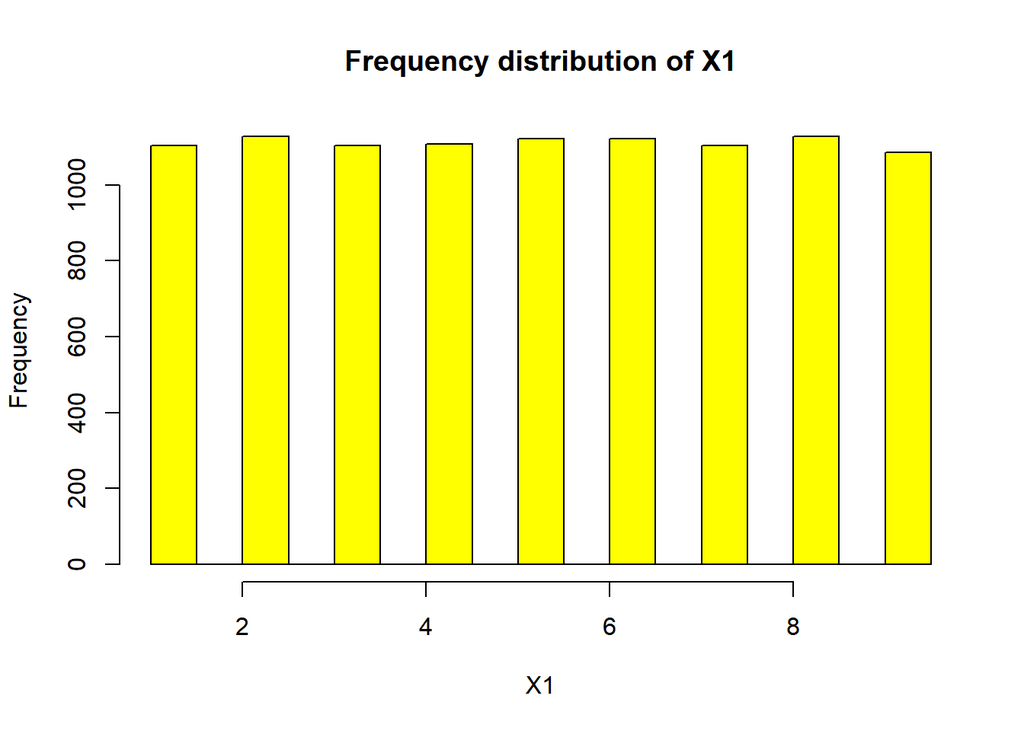

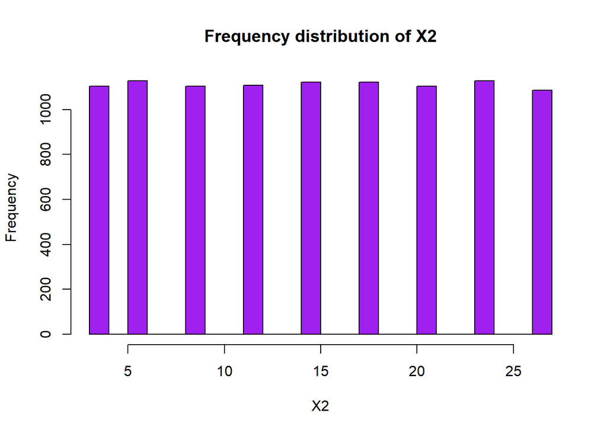

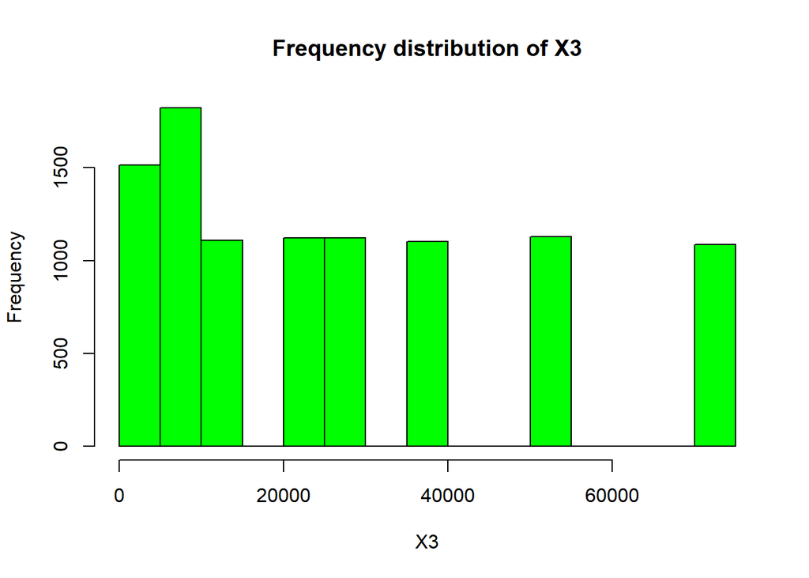

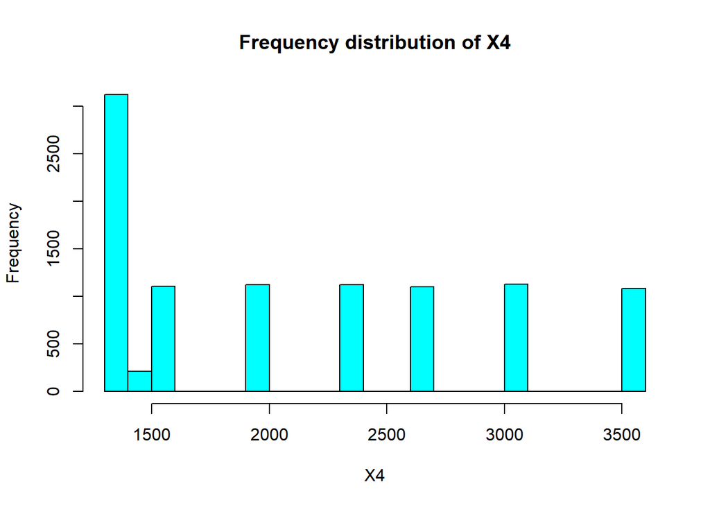

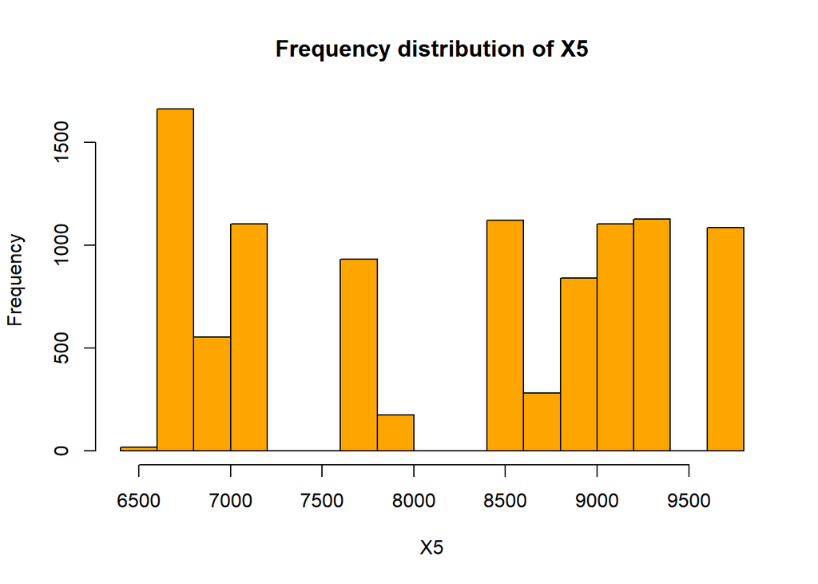

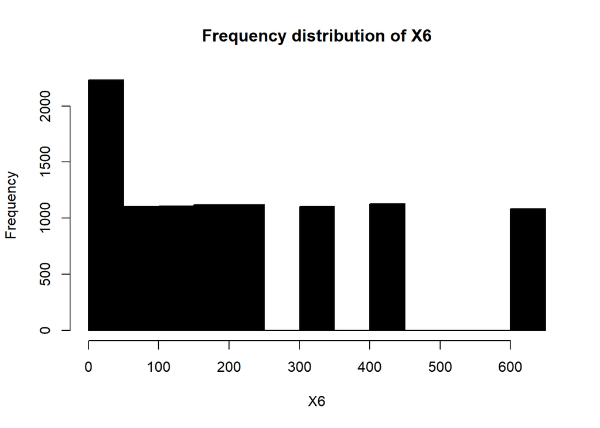

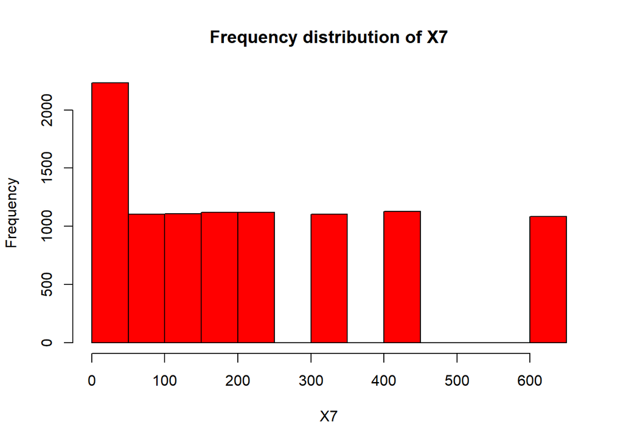

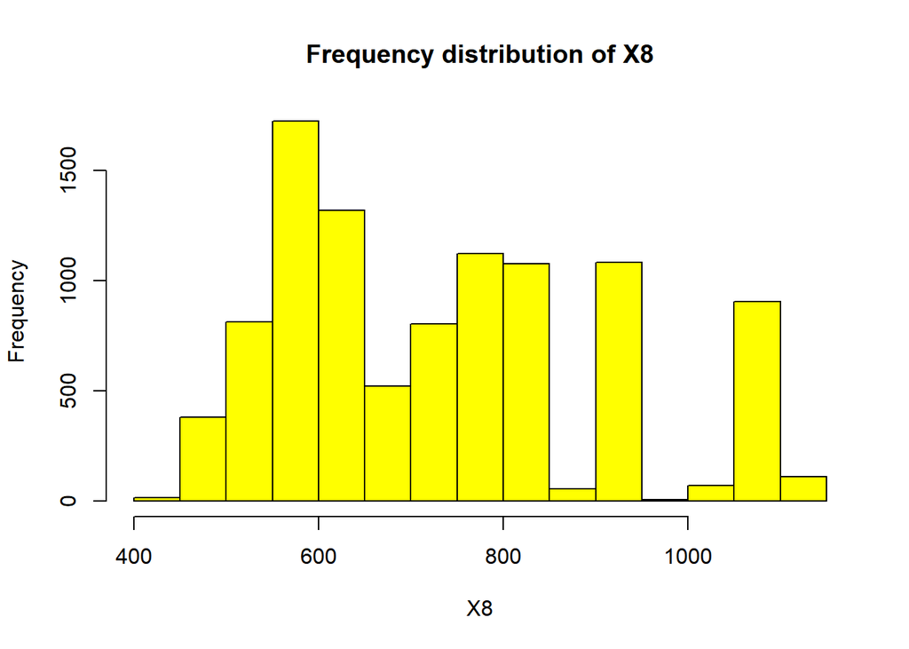

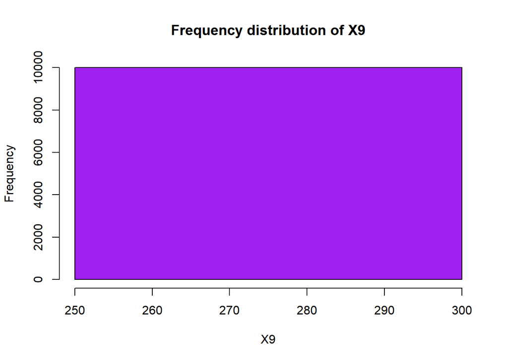

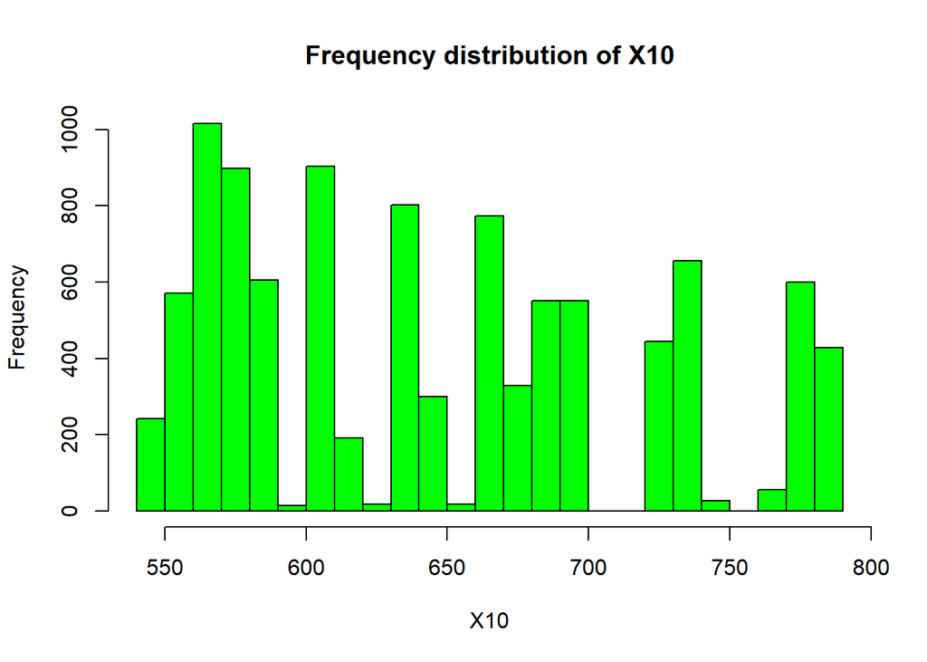

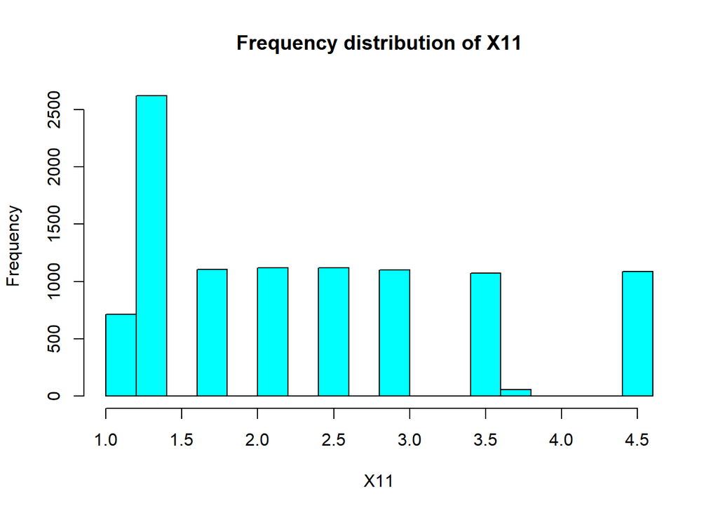

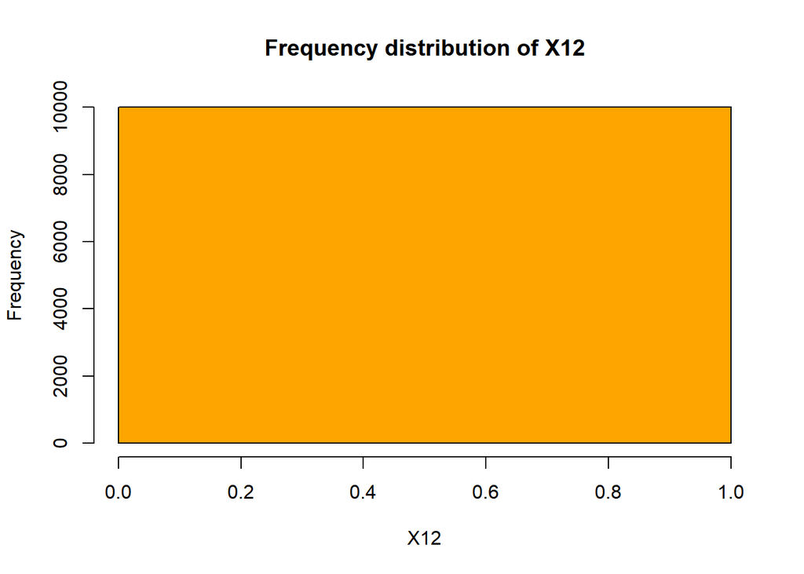

[4 more figures not shown]

```r
colorsInR <- c("red","yellow","purple","green","cyan","orange","black")

# histogram plots for X
  for ( i in seq(1,16) ){
    hist(navalData[[i]], breaks=20, main= paste("Frequency distribution of X",i,sep=""), col=colorsInR[i%%7+1], xlab= paste("X",i,sep=""))
  }
```

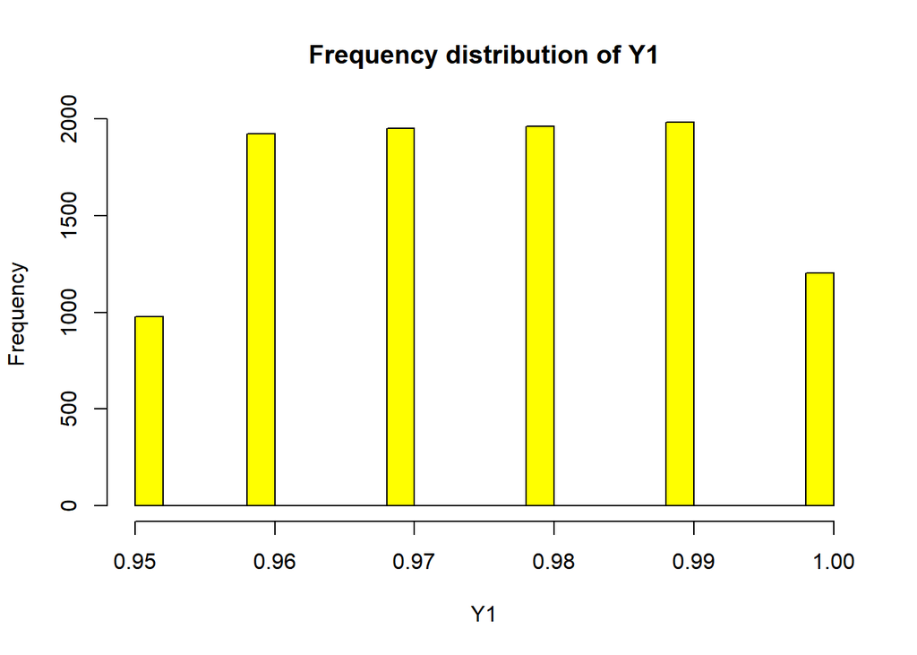

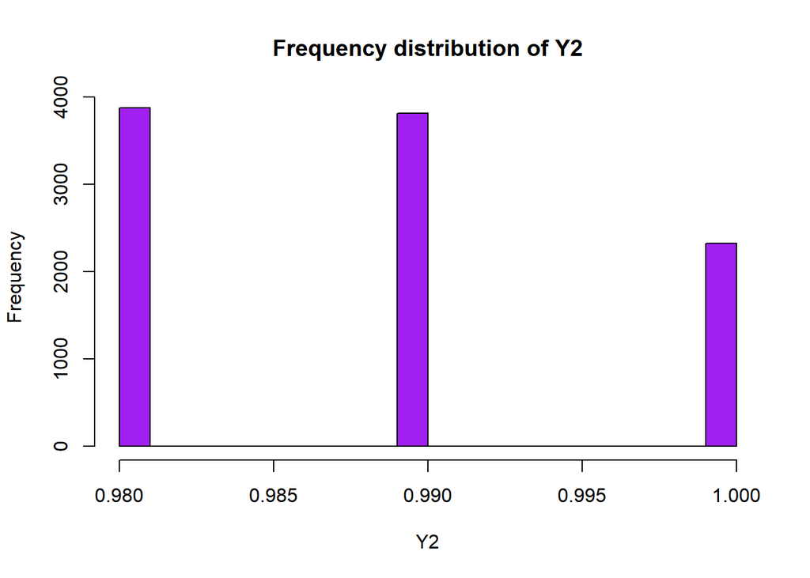

```r
#histogram plot for Y
for ( i in seq(1,2) ){
    hist(navalData[[i+16]], breaks=20, main= paste("Frequency distribution of Y",i,sep=""), col=colorsInR[i%%7+1], xlab= paste("Y",i,sep=""))
  }
```

### Observation 3: The data distribution is sparse for some variables like `X4` and `X5`. `X7`, `X11`, `X16`, and `X6` have visible outliers which should be explored via boxplots

## Aim 4:

Generate boxplots for variables

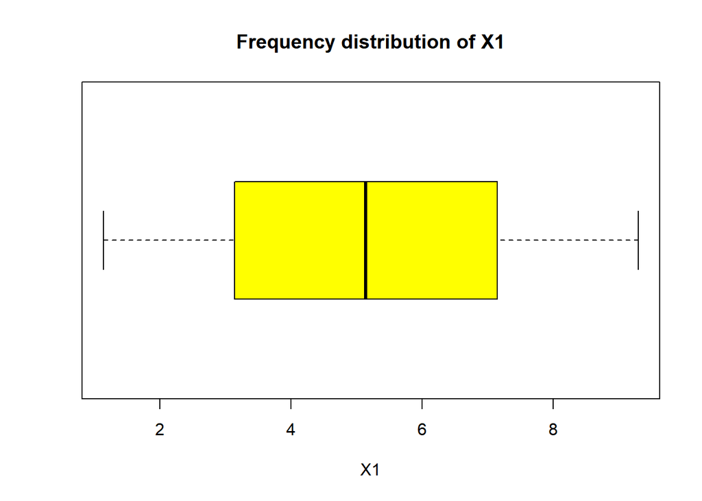

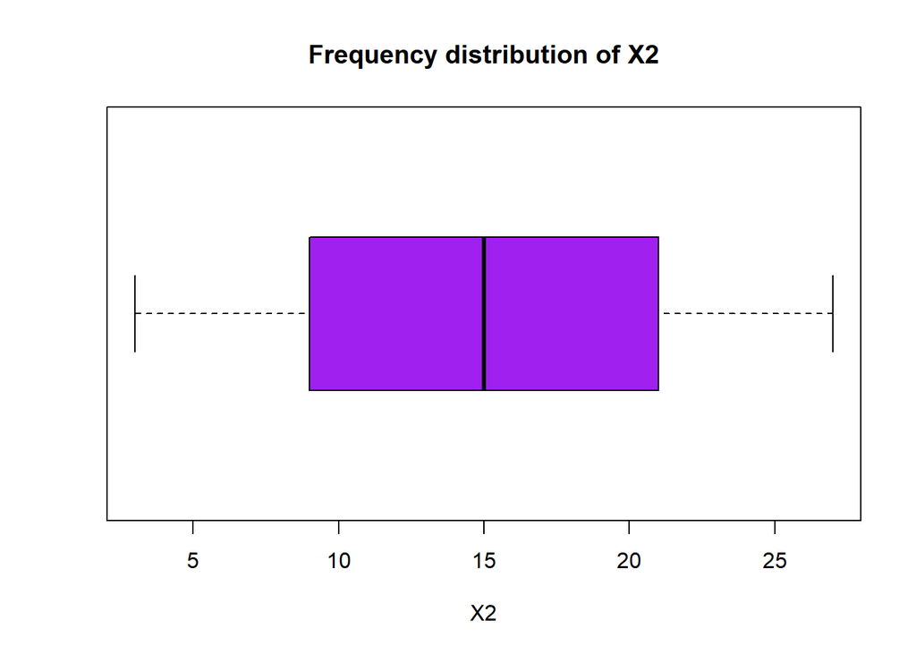

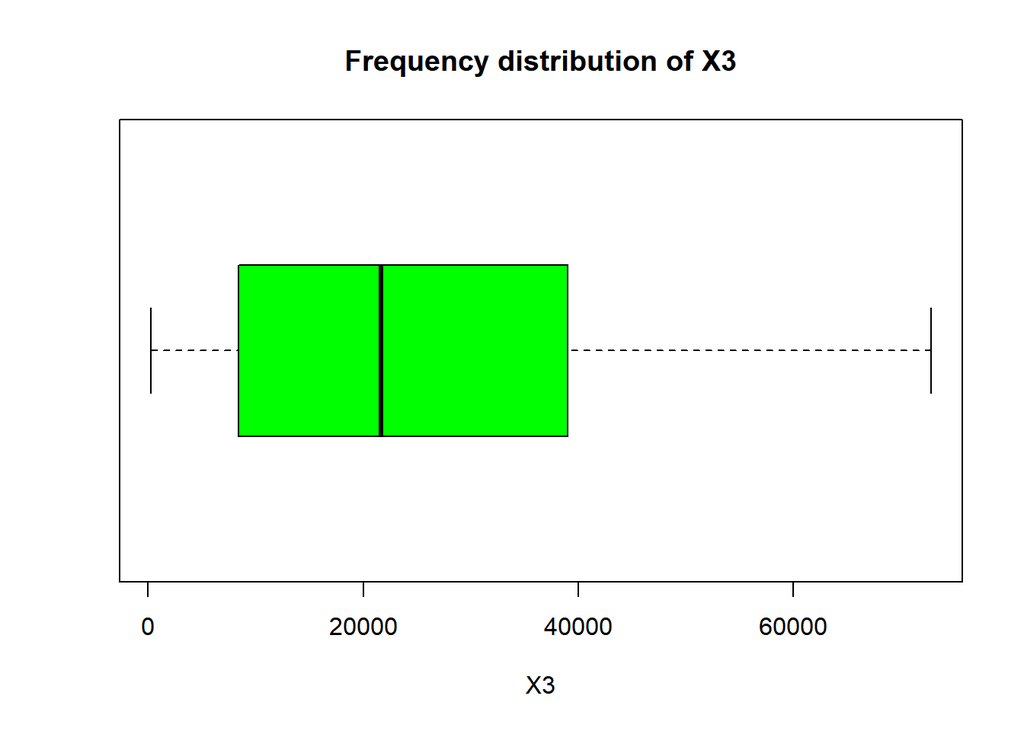

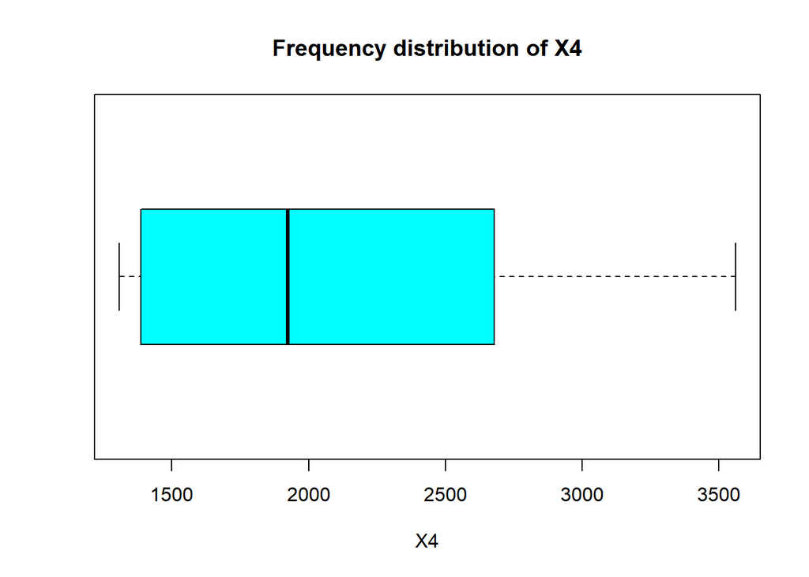

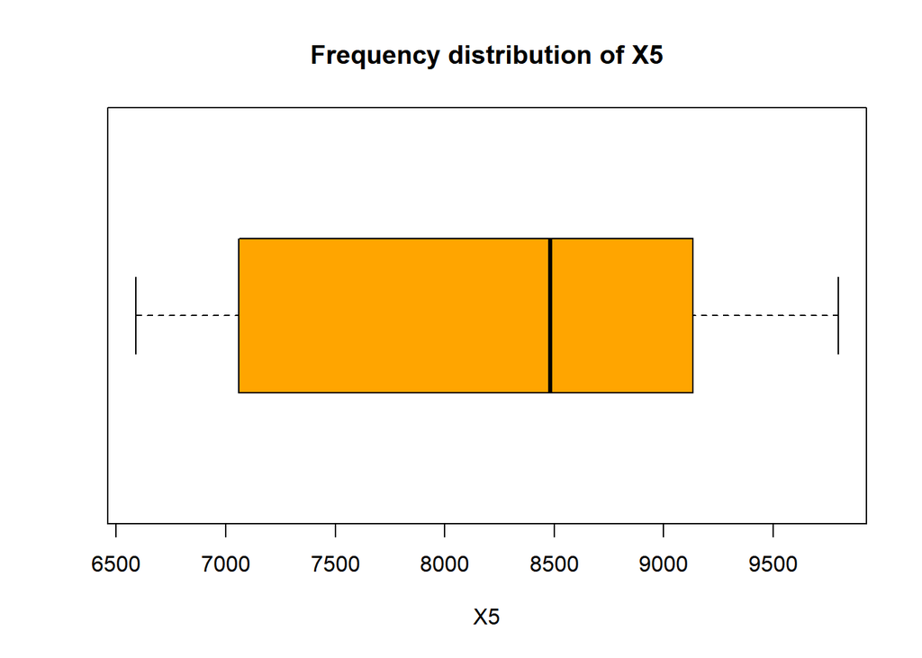

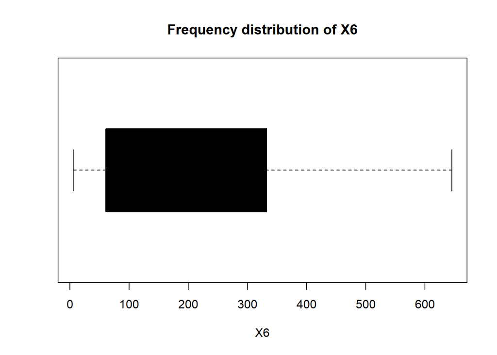

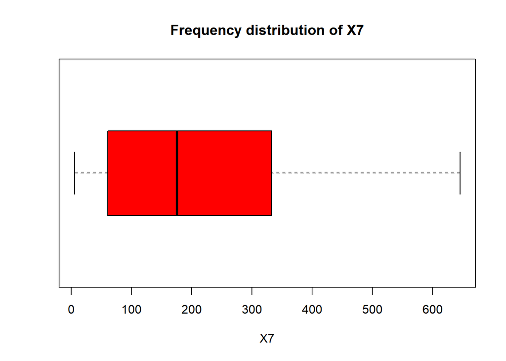

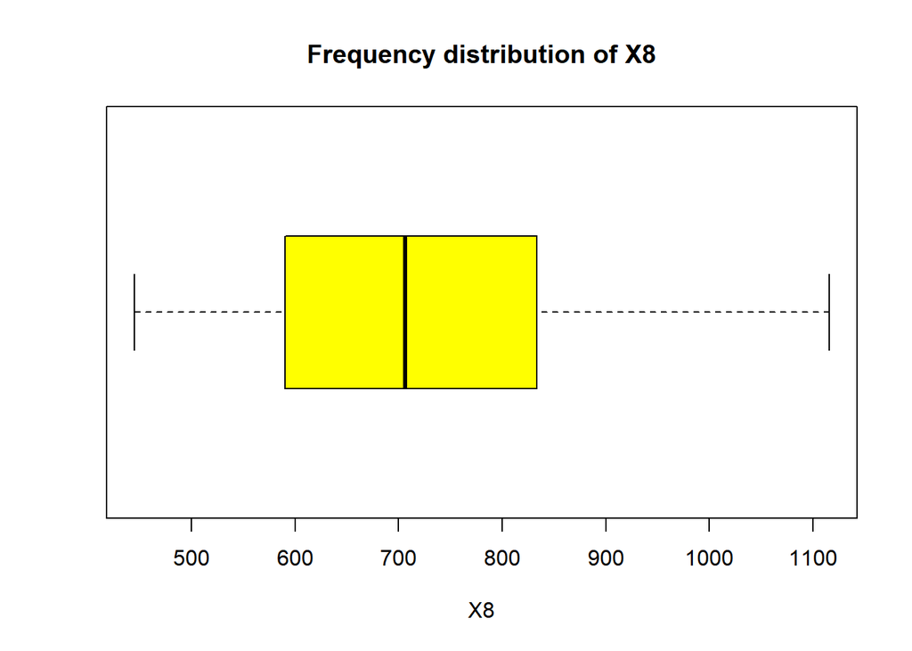

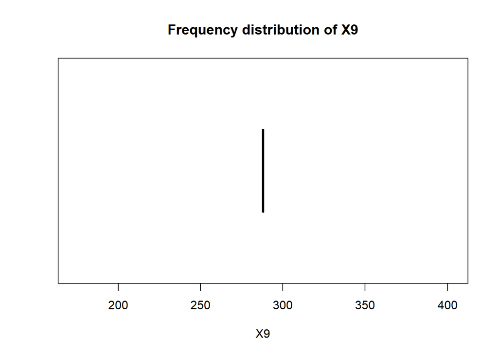

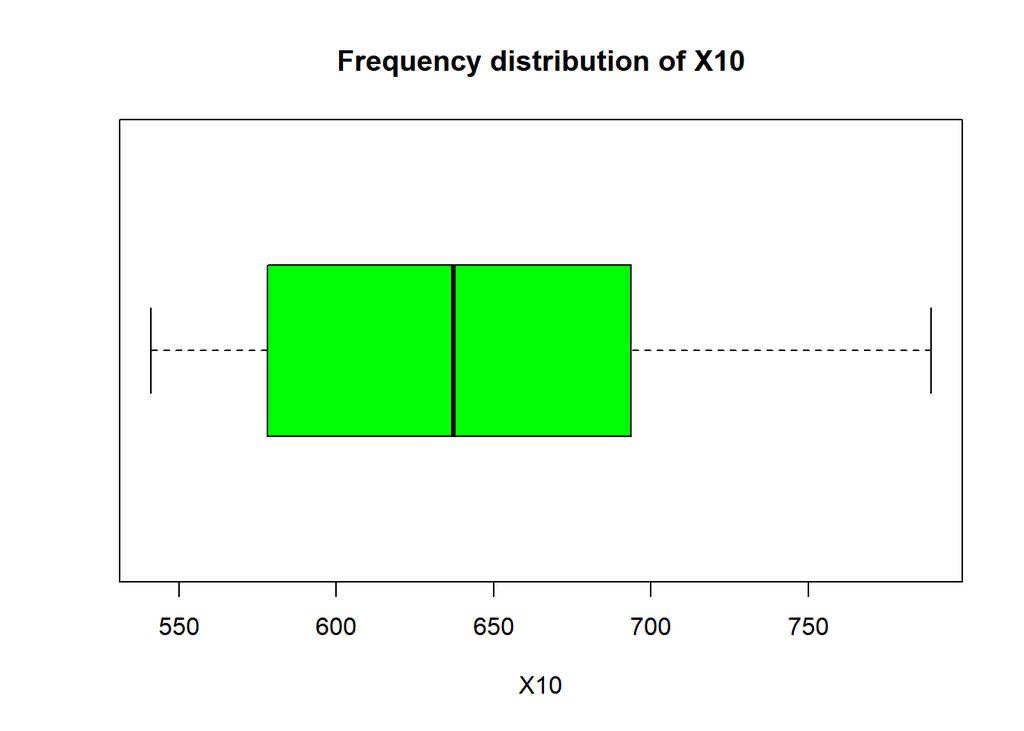

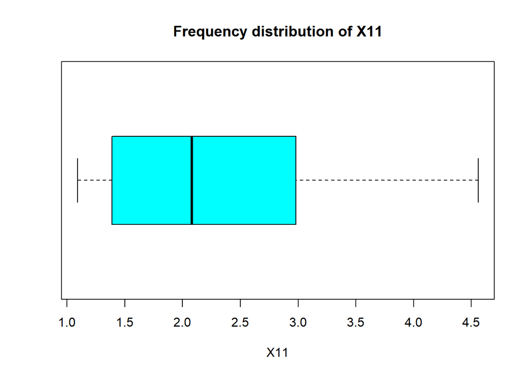

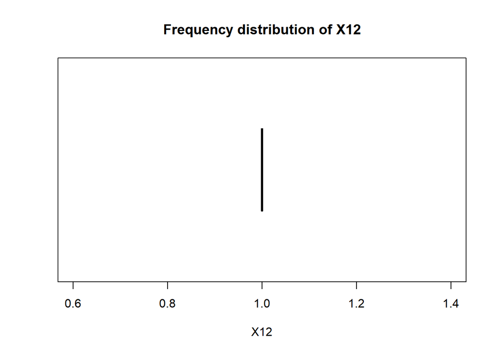

[4 more figures not shown]

```r
# boxplots for Xs
  for ( i in seq(1,16) ){
    boxplot(navalData[[i]], horizontal= TRUE, main= paste("Frequency distribution of X",i,sep=""), col=colorsInR[i%%7+1], xlab= paste("X",i,sep=""))
  }
```

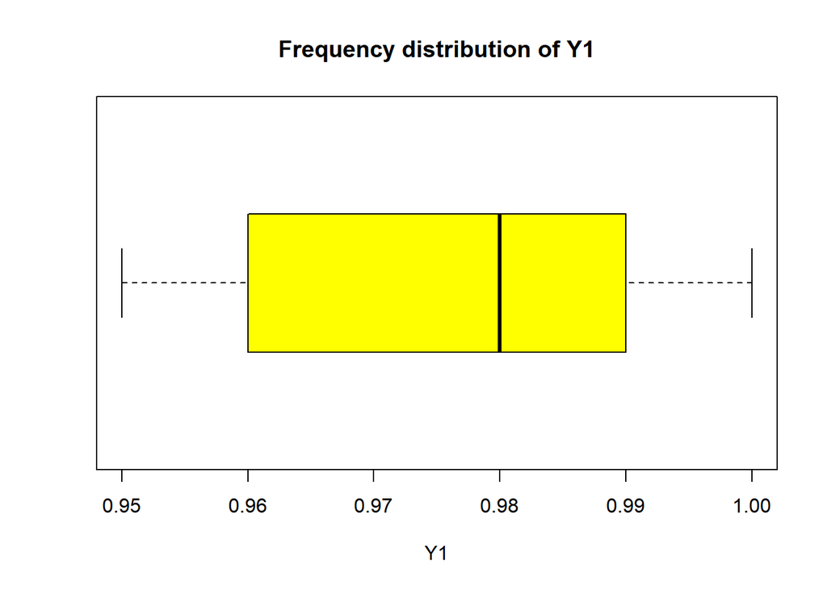

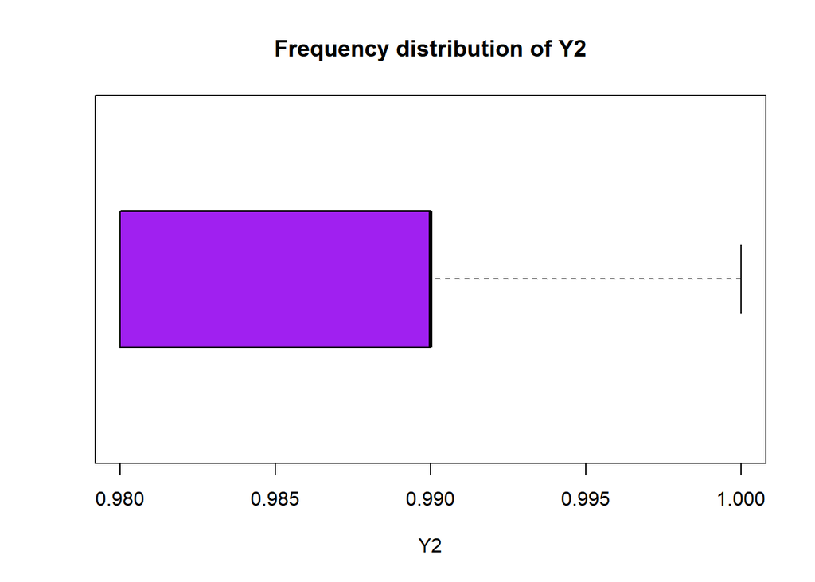

```r
#histogram plot for Ys
for ( i in seq(1,2) ){
    boxplot(navalData[[i+16]], horizontal= TRUE, main= paste("Frequency distribution of Y",i,sep=""), col=colorsInR[i%%7+1], xlab= paste("Y",i,sep=""))
  }
```

### Observation 4:

Data distribution of some variables is highly concentrated/ approximately skewed Gaussian (example `X16`). We can remove the constant variables that is `X9` and `X12` from our data observations as they do not contribute to any change in output variables `Y1` and `Y2`.

## Aim 5:

Generate correlation between variables

```r
navalDataRefined1 <- navalData[-c(9,12)]

  cor(navalDataRefined1)
```

```
##               X1           X2           X3           X4           X5
## X1   1.000000000  0.999918932  0.961060859  0.962170527  0.986018461
## X2   0.999918932  1.000000000  0.958307867  0.960416376  0.986548821
## X3   0.961060859  0.958307867  1.000000000  0.989710627  0.932836760
## X4   0.962170527  0.960416376  0.989710627  1.000000000  0.942750924
## X5   0.986018461  0.986548821  0.932836760  0.942750924  1.000000000
## X6   0.959275784  0.956445990  0.999172632  0.988613230  0.929454314
## X7   0.959275784  0.956445990  0.999172632  0.988613230  0.929454314
## X8   0.961363106  0.958975323  0.991117108  0.979605879  0.939689075
## X10  0.982901522  0.981293328  0.990183964  0.989218702  0.966616938
## X11  0.963095924  0.960647472  0.998888416  0.995108006  0.937287676
## X13  0.969167929  0.967014773  0.997576076  0.996031986  0.945731565
## X14  0.939948005  0.938787319  0.972969659  0.982595630  0.930584897
## X15  0.912781187  0.909186053  0.977483586  0.961994252  0.878080018
## X16  0.931333951  0.927768436  0.995035351  0.980197416  0.896626923
## Y1  -0.006831136 -0.006896537 -0.002047114 -0.003118643 -0.025153234
## Y2  -0.004758308 -0.004737331 -0.004087297 -0.004376194  0.005878501
##               X6           X7          X8         X10          X11          X13
## X1   0.959275784  0.959275784  0.96136311  0.98290152  0.963095924  0.969167929
## X2   0.956445990  0.956445990  0.95897532  0.98129333  0.960647472  0.967014773
## X3   0.999172632  0.999172632  0.99111711  0.99018396  0.998888416  0.997576076
## X4   0.988613230  0.988613230  0.97960588  0.98921870  0.995108006  0.996031986
## X5   0.929454314  0.929454314  0.93968908  0.96661694  0.937287676  0.945731565
## X6   1.000000000  1.000000000  0.98594120  0.98733461  0.997995101  0.996164013
## X7   1.000000000  1.000000000  0.98594120  0.98733461  0.997995101  0.996164013
## X8   0.985941204  0.985941204  1.00000000  0.99228188  0.989368313  0.990447825
## X10  0.987334609  0.987334609  0.99228188  1.00000000  0.991669537  0.994336058
## X11  0.997995101  0.997995101  0.98936831  0.99166954  1.000000000  0.999397450
## X13  0.996164013  0.996164013  0.99044783  0.99433606  0.999397450  1.000000000
## X14  0.972923822  0.972923822  0.96133975  0.96767519  0.978193788  0.978681796
## X15  0.977039542  0.977039542  0.96927553  0.95811467  0.975334806  0.971710488
## X16  0.994307212  0.994307212  0.98623588  0.97630253  0.992683665  0.989216457
## Y1  -0.004261568 -0.004261568 -0.04428452 -0.05189850  0.002945739  0.003249422
## Y2  -0.004578771 -0.004578771 -0.03974577 -0.02004147 -0.006871948 -0.021517833
##              X14         X15         X16           Y1           Y2
## X1   0.939948005  0.91278119  0.93133395 -0.006831136 -0.004758308
## X2   0.938787319  0.90918605  0.92776844 -0.006896537 -0.004737331
## X3   0.972969659  0.97748359  0.99503535 -0.002047114 -0.004087297
## X4   0.982595630  0.96199425  0.98019742 -0.003118643 -0.004376194
## X5   0.930584897  0.87808002  0.89662692 -0.025153234  0.005878501
## X6   0.972923822  0.97703954  0.99430721 -0.004261568 -0.004578771
## X7   0.972923822  0.97703954  0.99430721 -0.004261568 -0.004578771
## X8   0.961339751  0.96927553  0.98623588 -0.044284518 -0.039745766
## X10  0.967675185  0.95811467  0.97630253 -0.051898504 -0.020041470
## X11  0.978193788  0.97533481  0.99268366  0.002945739 -0.006871948
## X13  0.978681796  0.97171049  0.98921646  0.003249422 -0.021517833
## X14  1.000000000  0.94932212  0.96452928 -0.005631884 -0.002865694
## X15  0.949322120  1.00000000  0.98533613 -0.035551428 -0.021399292
## X16  0.964529281  0.98533613  1.00000000 -0.017788588 -0.020441146
## Y1  -0.005631884 -0.03555143 -0.01778859  1.000000000 -0.001220496
## Y2  -0.002865694 -0.02139929 -0.02044115 -0.001220496  1.000000000
```

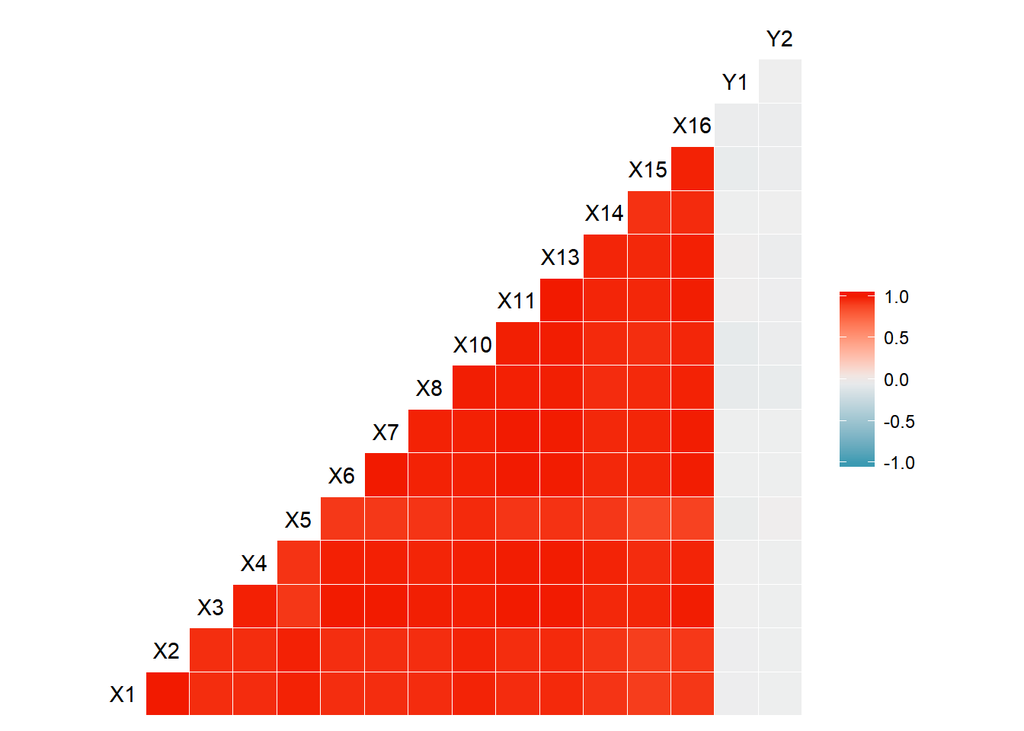

```r
  library(GGally)
  ggcorr(navalDataRefined1, geom="tile")
```

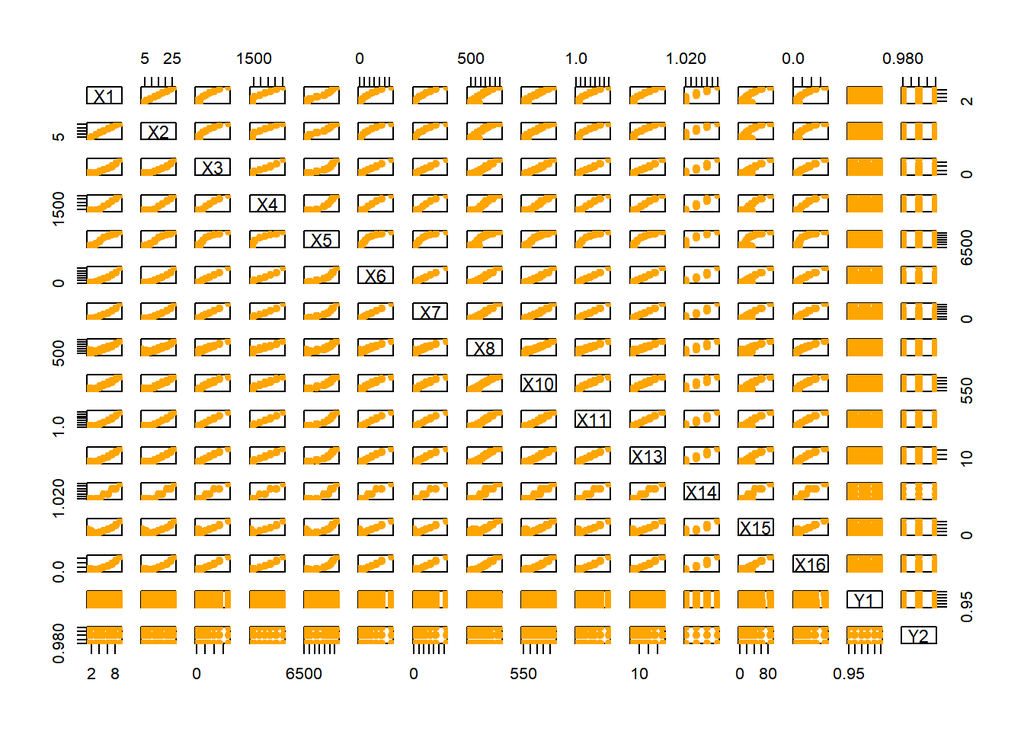

```r
  # Plotting two-dimensional scatterplots of all pairs of variables
  pairs(navalDataRefined1, pch = 19, col = "orange")
```

### Observation 5:

We can observe from correlation plot and correlation values that all the input values are highly correlated to each other and `X6` and `X7` have a correlation equal to **1**. Hence, we can remove one of the variable for analyzing the effect on output of input variables on output variables `Y1` and `Y2`. {Reasoning- Starboard and port side torque shoule be same for the ship to propel forward in a straight line}. The output variables `Y1` and `Y2` have almost no corelation.

# ————————————————————————————————

# Part 2: Linear Model

```r
#adjusting data and initializing training data and test data for the linear model to be built
navalDataRefined2 <- navalData[-c(9,12,7)]
set.seed(1)
row.number <- sample(1:nrow(navalDataRefined2),0.8*nrow(navalDataRefined2))
trainData = navalDataRefined2[row.number,]
testData  = navalDataRefined2[-row.number,]
```

## Aim 6:

Create linear model for Y1 and use Adjusted R-squared as the metric to determine if the model is improving. (Multiple R-squared doesn’t properly reflect removal of insignificant variable)

```r
lmFitY1_Attempt1 <- lm(Y1 ~ .,data = trainData[,-15])
summary(lmFitY1_Attempt1)
```

```
##
## Call:
## lm(formula = Y1 ~ ., data = trainData[, -15])
##
## Residuals:
##        Min         1Q     Median         3Q        Max
## -0.0180951 -0.0041676  0.0000462  0.0042030  0.0197351
##
## Coefficients:
##               Estimate Std. Error  t value Pr(>|t|)
## (Intercept)  4.798e+00  7.322e-02   65.518   <2e-16 ***
## X1           1.441e-01  6.496e-03   22.182   <2e-16 ***
## X2          -3.973e-02  2.043e-03  -19.449   <2e-16 ***
## X3          -3.527e-06  4.084e-07   -8.637   <2e-16 ***
## X4          -2.190e-08  3.328e-06   -0.007    0.995
## X5           4.209e-05  9.779e-07   43.037   <2e-16 ***
## X6          -5.629e-04  3.645e-05  -15.444   <2e-16 ***
## X8           2.888e-04  2.234e-05   12.931   <2e-16 ***
## X10         -4.162e-03  4.111e-05 -101.242   <2e-16 ***
## X11          2.089e-01  9.401e-03   22.224   <2e-16 ***
## X13          1.398e-02  9.600e-04   14.563   <2e-16 ***
## X14         -2.278e+00  6.816e-02  -33.413   <2e-16 ***
## X15         -6.200e-04  2.005e-05  -30.931   <2e-16 ***
## X16          1.332e-01  1.209e-02   11.018   <2e-16 ***
## ---
## Signif. codes:  0 '***' 0.001 '**' 0.01 '*' 0.05 '.' 0.1 ' ' 1
##
## Residual standard error: 0.006139 on 7986 degrees of freedom
## Multiple R-squared:  0.8397, Adjusted R-squared:  0.8394
## F-statistic:  3217 on 13 and 7986 DF,  p-value: < 2.2e-16
```

```r
#step(lmFitY1_Attempt1, direction = "backward")
```

### Observation 6:

`X4` has an observably high p-value and can be an insignificant contribution for predicting `Y1`

## Aim 7:

Create linear model for Y1 and find affect on model prediction of Y1

```r
lmFitY1_Attempt2 <- update(lmFitY1_Attempt1, ~ . - X4, data = trainData[,-15])
summary(lmFitY1_Attempt2)
```

```
##
## Call:
## lm(formula = Y1 ~ X1 + X2 + X3 + X5 + X6 + X8 + X10 + X11 + X13 +
##     X14 + X15 + X16, data = trainData[, -15])
##
## Residuals:
##        Min         1Q     Median         3Q        Max
## -0.0180949 -0.0041677  0.0000463  0.0042026  0.0197351
##
## Coefficients:
##               Estimate Std. Error  t value Pr(>|t|)
## (Intercept)  4.798e+00  6.892e-02   69.614   <2e-16 ***
## X1           1.441e-01  6.348e-03   22.703   <2e-16 ***
## X2          -3.973e-02  2.010e-03  -19.767   <2e-16 ***
## X3          -3.527e-06  4.006e-07   -8.803   <2e-16 ***
## X5           4.209e-05  9.113e-07   46.186   <2e-16 ***
## X6          -5.629e-04  3.642e-05  -15.453   <2e-16 ***
## X8           2.888e-04  2.226e-05   12.973   <2e-16 ***
## X10         -4.162e-03  3.403e-05 -122.318   <2e-16 ***
## X11          2.089e-01  8.108e-03   25.764   <2e-16 ***
## X13          1.398e-02  9.568e-04   14.611   <2e-16 ***
## X14         -2.278e+00  6.659e-02  -34.207   <2e-16 ***
## X15         -6.200e-04  1.996e-05  -31.056   <2e-16 ***
## X16          1.332e-01  1.148e-02   11.604   <2e-16 ***
## ---
## Signif. codes:  0 '***' 0.001 '**' 0.01 '*' 0.05 '.' 0.1 ' ' 1
##
## Residual standard error: 0.006139 on 7987 degrees of freedom
## Multiple R-squared:  0.8397, Adjusted R-squared:  0.8394
## F-statistic:  3486 on 12 and 7987 DF,  p-value: < 2.2e-16
```

### Observation 7:

Change in Adjusted R-squared value is 0.0000 (value remians 0.8394) and hence removal of `X4` doesn’t detoriate the model fitting.

## Aim 8:

Removal/Treatment of outliers for better linear model prediction of `Y1`

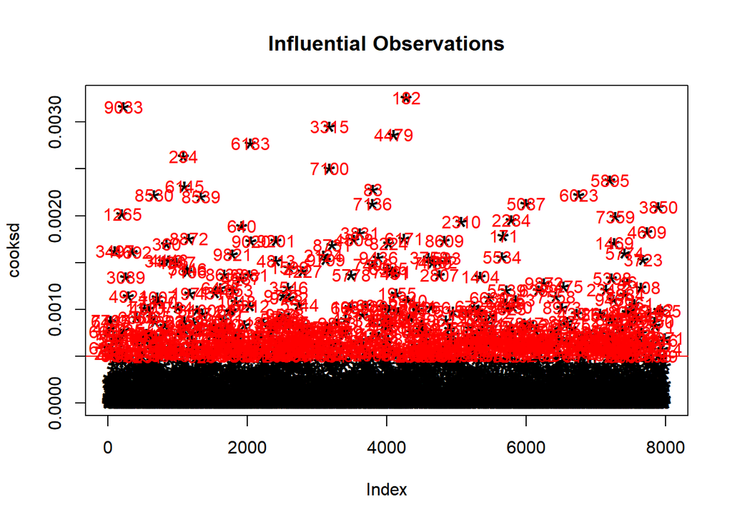

```r
# For univariate and bivariate model, outlier can be detected and treated using boxplots. For multi-variate model we use Cook's distance
cooksd <- cooks.distance(lmFitY1_Attempt2)
plot(cooksd, pch="*", cex=2, main="Influential Observations")  # plot cook's distance
abline(h = abs(4/(nrow(trainData)-1)), col="red")  # add cutoff line
text(x=1:length(cooksd)+1, y=cooksd, labels=ifelse(cooksd>abs(4/(nrow(trainData)-1)),names(cooksd),""), col="red")  # add labels
```

```r
# Observations with Cook distance greater than 4/(n - p -1) where n is the number of observations and p is the number of input features should be eliminated to take care of the outliers

navalDataRefined3 <- trainData[abs(cooksd)<4/(nrow(trainData)-1),]
lmFitY1_Attempt3 <- lm(formula(lmFitY1_Attempt2), data = navalDataRefined3[,-15])
summary(lmFitY1_Attempt3)
```

```
##
## Call:
## lm(formula = formula(lmFitY1_Attempt2), data = navalDataRefined3[,
##     -15])
##
## Residuals:
##        Min         1Q     Median         3Q        Max
## -0.0149621 -0.0038225 -0.0000148  0.0038548  0.0138140
##
## Coefficients:
##               Estimate Std. Error  t value Pr(>|t|)
## (Intercept)  4.576e+00  6.248e-02   73.244  < 2e-16 ***
## X1           1.529e-01  5.783e-03   26.442  < 2e-16 ***
## X2          -4.204e-02  1.839e-03  -22.863  < 2e-16 ***
## X3          -6.747e-07  3.654e-07   -1.847   0.0649 .
## X5           4.672e-05  8.165e-07   57.220  < 2e-16 ***
## X6          -8.943e-04  3.371e-05  -26.532  < 2e-16 ***
## X8           9.666e-05  2.058e-05    4.696  2.7e-06 ***
## X10         -3.975e-03  3.102e-05 -128.137  < 2e-16 ***
## X11          1.624e-01  7.303e-03   22.231  < 2e-16 ***
## X13          1.730e-02  8.699e-04   19.891  < 2e-16 ***
## X14         -2.081e+00  6.008e-02  -34.639  < 2e-16 ***
## X15         -7.245e-04  1.879e-05  -38.565  < 2e-16 ***
## X16          2.249e-01  1.042e-02   21.579  < 2e-16 ***
## ---
## Signif. codes:  0 '***' 0.001 '**' 0.01 '*' 0.05 '.' 0.1 ' ' 1
##
## Residual standard error: 0.005329 on 7485 degrees of freedom
## Multiple R-squared:  0.8715, Adjusted R-squared:  0.8713
## F-statistic:  4230 on 12 and 7485 DF,  p-value: < 2.2e-16
```

### Observation 8:

There is an increase in Adjusted R-squared value from 0.8394 to 0.8713 implying the improvement of linear model. There is also a high p-value after removal of outlier: `X3`. It’s impact on removal needs to be tested.

## Aim 9:

To test impact of removal of `X3` from the input variables for output `Y1`

```r
lmFitY1_Attempt4 <- update(lmFitY1_Attempt3, ~ . - X3, data = trainData[,-15])
summary(lmFitY1_Attempt4)
```

```
##
## Call:
## lm(formula = Y1 ~ X1 + X2 + X5 + X6 + X8 + X10 + X11 + X13 +
##     X14 + X15 + X16, data = trainData[, -15])
##
## Residuals:
##        Min         1Q     Median         3Q        Max
## -0.0189008 -0.0041338 -0.0000016  0.0042169  0.0198379
##
## Coefficients:
##               Estimate Std. Error t value Pr(>|t|)
## (Intercept)  4.595e+00  6.526e-02   70.41   <2e-16 ***
## X1           1.371e-01  6.327e-03   21.66   <2e-16 ***
## X2          -3.736e-02  2.001e-03  -18.66   <2e-16 ***
## X5           4.252e-05  9.143e-07   46.51   <2e-16 ***
## X6          -8.169e-04  2.233e-05  -36.59   <2e-16 ***
## X8           1.250e-04  1.227e-05   10.19   <2e-16 ***
## X10         -3.934e-03  2.219e-05 -177.30   <2e-16 ***
## X11          1.497e-01  4.544e-03   32.94   <2e-16 ***
## X13          1.899e-02  7.724e-04   24.59   <2e-16 ***
## X14         -2.096e+00  6.362e-02  -32.95   <2e-16 ***
## X15         -6.287e-04  2.004e-05  -31.38   <2e-16 ***
## X16          1.730e-01  1.060e-02   16.33   <2e-16 ***
## ---
## Signif. codes:  0 '***' 0.001 '**' 0.01 '*' 0.05 '.' 0.1 ' ' 1
##
## Residual standard error: 0.006168 on 7988 degrees of freedom
## Multiple R-squared:  0.8381, Adjusted R-squared:  0.8379
## F-statistic:  3760 on 11 and 7988 DF,  p-value: < 2.2e-16
```

### Observation 9:

```r
mse_lmY1 <- mean(testData[["Y1"]] - predict(lmFitY1_Attempt3, testData))^2
mse_lmY1
```

```
## [1] 4.325837e-08
```

## Aim 10:

Generate best fitting model for `Y2`

```r
lmFitY2_Attempt1 <- lm(Y2 ~ .,data = trainData[,-14])
summary(lmFitY2_Attempt1)
```

```
##
## Call:
## lm(formula = Y2 ~ ., data = trainData[, -14])
##
## Residuals:
##        Min         1Q     Median         3Q        Max
## -0.0114790 -0.0026357  0.0000456  0.0025777  0.0130138
##
## Coefficients:
##               Estimate Std. Error t value Pr(>|t|)
## (Intercept)  4.141e-01  4.241e-02   9.766  < 2e-16 ***
## X1           2.460e-02  3.762e-03   6.539 6.57e-11 ***
## X2          -2.816e-03  1.183e-03  -2.380   0.0173 *
## X3           1.365e-05  2.365e-07  57.735  < 2e-16 ***
## X4           4.801e-05  1.927e-06  24.912  < 2e-16 ***
## X5           2.062e-05  5.663e-07  36.407  < 2e-16 ***
## X6          -1.489e-03  2.111e-05 -70.549  < 2e-16 ***
## X8          -6.392e-04  1.294e-05 -49.411  < 2e-16 ***
## X10          3.600e-04  2.381e-05  15.122  < 2e-16 ***
## X11          1.037e-01  5.445e-03  19.050  < 2e-16 ***
## X13         -5.089e-02  5.560e-04 -91.534  < 2e-16 ***
## X14          6.101e-01  3.948e-02  15.454  < 2e-16 ***
## X15         -1.545e-04  1.161e-05 -13.312  < 2e-16 ***
## X16          2.719e-01  6.999e-03  38.852  < 2e-16 ***
## ---
## Signif. codes:  0 '***' 0.001 '**' 0.01 '*' 0.05 '.' 0.1 ' ' 1
##
## Residual standard error: 0.003555 on 7986 degrees of freedom
## Multiple R-squared:  0.7873, Adjusted R-squared:  0.7869
## F-statistic:  2273 on 13 and 7986 DF,  p-value: < 2.2e-16
```

## Aim 11:

Study the effect of removal of `X2` from linear model of Y2

```r
lmFitY2_Attempt2 <- update(lmFitY2_Attempt1, ~ . - X2, data = trainData[,-14])
summary(lmFitY2_Attempt2)
```

```
##
## Call:
## lm(formula = Y2 ~ X1 + X3 + X4 + X5 + X6 + X8 + X10 + X11 + X13 +
##     X14 + X15 + X16, data = trainData[, -14])
##
## Residuals:
##       Min        1Q    Median        3Q       Max
## -0.011376 -0.002641  0.000043  0.002571  0.013073
##
## Coefficients:
##               Estimate Std. Error t value Pr(>|t|)
## (Intercept)  4.699e-01  3.537e-02   13.29   <2e-16 ***
## X1           1.568e-02  3.152e-04   49.74   <2e-16 ***
## X3           1.371e-05  2.355e-07   58.21   <2e-16 ***
## X4           4.720e-05  1.897e-06   24.88   <2e-16 ***
## X5           2.088e-05  5.560e-07   37.55   <2e-16 ***
## X6          -1.482e-03  2.088e-05  -70.95   <2e-16 ***
## X8          -6.400e-04  1.293e-05  -49.48   <2e-16 ***
## X10          3.686e-04  2.353e-05   15.66   <2e-16 ***
## X11          1.032e-01  5.443e-03   18.97   <2e-16 ***
## X13         -5.069e-02  5.500e-04  -92.16   <2e-16 ***
## X14          5.516e-01  3.092e-02   17.84   <2e-16 ***
## X15         -1.501e-04  1.146e-05  -13.10   <2e-16 ***
## X16          2.696e-01  6.930e-03   38.90   <2e-16 ***
## ---
## Signif. codes:  0 '***' 0.001 '**' 0.01 '*' 0.05 '.' 0.1 ' ' 1
##
## Residual standard error: 0.003556 on 7987 degrees of freedom
## Multiple R-squared:  0.7871, Adjusted R-squared:  0.7868
## F-statistic:  2461 on 12 and 7987 DF,  p-value: < 2.2e-16
```

### Observation 11:

There is marginal difference (of 0.0001) in Adjusted R-squared value after removal of input variable `X2` which is desirable. Hence, removal of X2 won’t impact the model prediction and X2 is “extra”.

## Aim 12:

Removal/Treatment of outliers for better linear model prediction of `Y2`

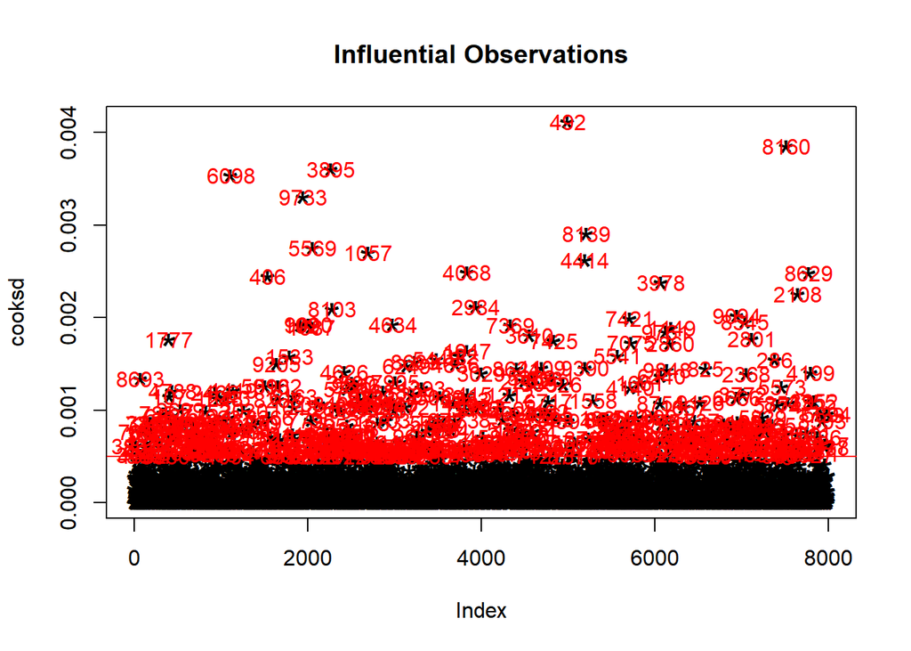

```r
# For univariate and bivariate model, outlier can be detected and treated using boxplots. For multi-variate model we use Cook's distance
cooksd <- cooks.distance(lmFitY2_Attempt2)
plot(cooksd, pch="*", cex=2, main="Influential Observations")  # plot cook's distance
abline(h = abs(4/(nrow(trainData)-1)), col="red")  # add cutoff line
text(x=1:length(cooksd)+1, y=cooksd, labels=ifelse(cooksd>abs(4/(nrow(trainData)-1)),names(cooksd),""), col="red")  # add labels
```

```r
# Observations with Cook distance greater than 4/(n - p -1) where n is the number of observations and p is the number of input features should be eliminated to take care of the outliers

navalDataRefined3 <- trainData[abs(cooksd)<4/(nrow(trainData)-1),]
lmFitY2_Attempt3 <- lm(formula(lmFitY2_Attempt2), data = navalDataRefined3[,-14])
summary(lmFitY2_Attempt3)
```

```
##
## Call:
## lm(formula = formula(lmFitY2_Attempt2), data = navalDataRefined3[,
##     -14])
##
## Residuals:
##        Min         1Q     Median         3Q        Max
## -0.0079668 -0.0024404  0.0000881  0.0024480  0.0093880
##
## Coefficients:
##               Estimate Std. Error t value Pr(>|t|)
## (Intercept)  4.382e-01  3.206e-02   13.67   <2e-16 ***
## X1           1.681e-02  3.024e-04   55.59   <2e-16 ***
## X3           1.459e-05  2.185e-07   66.75   <2e-16 ***
## X4           5.380e-05  1.758e-06   30.61   <2e-16 ***
## X5           2.150e-05  5.124e-07   41.95   <2e-16 ***
## X6          -1.548e-03  1.944e-05  -79.61   <2e-16 ***
## X8          -6.843e-04  1.205e-05  -56.80   <2e-16 ***
## X10          3.991e-04  2.175e-05   18.35   <2e-16 ***
## X11          8.364e-02  5.080e-03   16.46   <2e-16 ***
## X13         -5.059e-02  5.203e-04  -97.23   <2e-16 ***
## X14          5.915e-01  2.795e-02   21.16   <2e-16 ***
## X15         -2.020e-04  1.159e-05  -17.43   <2e-16 ***
## X16          2.937e-01  6.536e-03   44.93   <2e-16 ***
## ---
## Signif. codes:  0 '***' 0.001 '**' 0.01 '*' 0.05 '.' 0.1 ' ' 1
##
## Residual standard error: 0.003199 on 7595 degrees of freedom
## Multiple R-squared:  0.825,  Adjusted R-squared:  0.8247
## F-statistic:  2983 on 12 and 7595 DF,  p-value: < 2.2e-16
```

### Observation 12:

```r
mse_lmY2 <- mean(testData[["Y2"]] - predict(lmFitY2_Attempt3, testData))^2
mse_lmY2
```

```
## [1] 1.629803e-08
```

# ————————————————————————————————

# Part 3- Prediction of Y1 and Y2

## Aim 13: Generate predicted values of Y1 and Y2 on given dataset

```r
navalDataPred <- read.csv("assign1_NavalPred.csv", header = TRUE)
navalDataPredFiltered = subset(navalDataPred,select = -c(X7,X9,X12))


# Y1 fitting has removal of X4, X7, X9, X12
# Y2 fitting has removal of X2, X7, X9, X12
navalDataPredY1 = subset(navalDataPredFiltered, select = -c(X4))
navalDataPredY2 = subset(navalDataPredFiltered, select = -c(X2))

# Predict using lm

lmY1Pred = predict(lmFitY1_Attempt3,navalDataPredY1)
lmY2Pred = predict(lmFitY2_Attempt3,navalDataPredY2)

# Value of coefficient cannot be > 1
for(x in seq(1,1000)){
  if(lmY1Pred[x]>1){
    lmY1Pred[x] = 1
  }
  if(lmY2Pred[x]>1){
    lmY2Pred[x] = 1
  }
}

# Store and save predictions in .csv
lmYPredDataFrame <- data.frame("Y1"=lmY1Pred, "Y2"=lmY2Pred)
str(lmYPredDataFrame)
```

```
## 'data.frame':    1000 obs. of  2 variables:
##  $ Y1: num  0.975 0.97 0.959 0.957 0.989 ...
##  $ Y2: num  0.984 0.986 0.983 0.993 0.993 ...
```

```r
write.csv(lmYPredDataFrame, "assign1_NavalPred_LM.csv", row.names = TRUE)
```

## Aim 14:

Try fitting using non-linear models such as Random Forest and KNN Regressor.

```r
library(randomForest)
library(miscTools)
# Random Forest
randomForestY1 <- randomForest(Y1 ~ ., data = trainData[,-15], importance = TRUE)
randomForestY2 <- randomForest(Y2 ~ ., data = trainData[,-14], importance = TRUE)
#summary(randomForestY1)
#summary(randomForestY2)

#Calculating the R-squared and MSE using Random Forest Regressor.

r2_rf_Y1 <- rSquared(testData[["Y1"]], testData[["Y1"]] - predict (randomForestY1, testData))
r2_rf_Y2 <- rSquared(testData[["Y2"]], testData[["Y2"]] - predict (randomForestY2, testData))
mse_rf_Y1 <- mean(testData[["Y1"]] - predict(randomForestY1, testData))^2
mse_rf_Y2 <- mean(testData[["Y2"]] - predict(randomForestY2, testData))^2
r2_rf_Y1
```

```
##           [,1]
## [1,] 0.9699416
```

```r
r2_rf_Y2
```

```
##           [,1]
## [1,] 0.9486919
```

```r
mse_rf_Y1
```

```
## [1] 4.040275e-09
```

```r
mse_rf_Y2
```

```
## [1] 4.2658e-12
```

```r
library(FNN)
knnY1 <- knn.reg(train = trainData[,-14:-15], test = testData[,-14:-15], y = trainData[["Y1"]])
knnY2 <- knn.reg(train = trainData[,-14:-15], test = testData[,-14:-15], y = trainData[["Y2"]])

#Calculating the R-squared and MSE value from the knn model.

mse_knn_Y1 <- mean(testData[["Y1"]] - knnY1$pred)^2
mse_knn_Y2 <- mean(testData[["Y2"]] - knnY2$pred)^2
r2_knn_Y1 <- rSquared(testData[["Y1"]], testData[["Y1"]] - knnY1$pred)
r2_knn_Y2 <- rSquared(testData[["Y2"]], testData[["Y2"]] - knnY2$pred)
mse_knn_Y1
```

```
## [1] 1.137778e-08
```

```r
mse_knn_Y2
```

```
## [1] 8.402778e-09
```

```r
r2_knn_Y1
```

```
##           [,1]
## [1,] 0.9112322
```

```r
r2_knn_Y2
```

```
##           [,1]
## [1,] 0.8200369
```

[output not shown]

### Observation 14:

For predicting Y1- Random forest is best among the observed linear and non-linear models. For predicting Y2- Random forest is best among the observed linear and non-linear models.